# Assignment 1

Data 311: Machine Learning

Author

Affiliation

Dr. Irene Vrbik

UBC Okanagan

## Introduction

This assignment focuses on the analysis and prediction of the age of abalone, a type of marine mollusk, using physical measurements. Throughout this assignment, students will explore various linear and non-linear regression techniques, evaluate model performance, and consider the implications of multicollinearity and model selection criteria.

### Learning Outcomes

By the end of this assignment, students will be able to:

- Identify the type of problem (classification, regression, supervised, unsupervised) presented by the abalone dataset.
- Load and preprocess data in R, ensuring appropriate data types for each variable.
- Visualize data distributions and assess assumptions of the linear model using plots such as histograms and boxplots.
- Split data into training and testing sets and fit simple and multiple linear regression models to the training set.
- Evaluate model performance using metrics such as R-squared, Adjusted R-squared, and Mean Squared Error (MSE).
- Extend linear models by incorporating polynomial terms and categorical predictors, and assess their impact on model performance.
- Investigate multicollinearity using correlation matrices
- Implement forward selection to choose additional predictors for the regression model.
- Compare the predictive performance of different models and make informed decisions on model selection.
- Explore the use of K-Nearest Neighbors (KNN) regression and understand the bias-variance tradeoff in this context.
- Justify the choice of model based on diagnostic plots and model evaluation criteria.

### Abalone

The `abalone` dataset, available from the [UCI Machine Learning Repository](https://archive.ics.uci.edu/dataset/1/abalone), contains data related to physical measurements of abalones, a type of marine mollusk. Determining the age of an abalone traditionally involves cutting through the shell, staining it, and counting the number of rings under a microscope. In this portion of the assignment we seek aim to predict the age of abalone from physical measurements.

**Related material:** [Lab 1](https://irene.vrbik.ok.ubc.ca/quarto/machine-learning/labs/lab01.html) and [Lab 2](https://irene.vrbik.ok.ubc.ca/quarto/machine-learning/labs/lab2.html); Lectures [3](https://irene.vrbik.ok.ubc.ca/quarto/machine-learning/03-model-assessment.html), [4](https://irene.vrbik.ok.ubc.ca/quarto/machine-learning/04-linear-regression.html), and [5](https://irene.vrbik.ok.ubc.ca/quarto/machine-learning/05-mlr-ii.html)

## Exploratory / Pre-processing

**Exercise 1** (0.5 point) What type of problem is this? **Select all that apply.**

1. Classification
2. Regression
3. Supervised
4. Unsupervised
5. None of the above

**Exercise 2 (Data Preparation and Summary)** (0.5 point) Load the `abalone` dataset into R and ensure that each column is converted to the appropriate data type[^1]. Use the `str()` function to display the structure of your dataframe to verify that all columns have the correct data types.

**Exercise 3 (Data Visualization)** (1 point) Create a histogram and boxplot for the `Rings` variable, which represents the age of abalone. What do you observe about the distribution? Does this break any assumptions of the linear model? Why or why not?

**Exercise 4 (Split to train/test)** (1 point) Split the data into 50% training and 50% testing. Use your student number as the seed for reproducibility.

## Simple Linear Regression

For the exercises in this section, be sure to fit the models to the training set.

**Exercise 5 (SLR)** (1 point) Fit a simple linear regression model using `Rings` as the response variable and `Length` as the predictor. Display the summary of the model. Does there appear to be a significant relationship between these two variables?

**Exercise 6 (Coefficient of determination)** (1 point) State and interpret the coefficient of determination.

**Exercise 7 (Scatter plot and OLS fit)** (1 point) Plot the fitted regression line on a scatter plot of `Rings` versus `Length`. Again, be sure to use the training data.

**Exercise 8 (Checking Assumptions)** (1 point) Based on the scatter plot produced in the previous question, do the assumptions of linearity and homoscedasticity model appear to be satisfied? Justify your answer.

**Exercise 9 (Normality of Residuals)** (1 point) Run some diagnostic checks to investigate whether or not the normality of residuals assumption is reasonable.

## Multiple Linear Regression

**Exercise 10 (Polynomial Regression)** (1 point) Fit a polynomial regression model of degree 2 for `Length` (i.e., include `Length^2` as an additional predictor). Assess the significance of the quadratic term by examining the $p$-values, the adjusted R-squared value, and diagnostic plots for any potential violations of linear model assumptions.

**Exercise 11 (Categorical Predictor)** (1 point) Include `Sex` as a categorical predictor in the regression model along with `Length` as a continuous predictor. What is the impact of adding `Sex` on the model? Specifically, discuss the $p$-values for associated with the coefficient of `Sex` and the change in the adjusted R-squared value compared to the model using only `Length`.

**Exercise 12 (Parallel lines model)** (2 points) Write down the equation of the line for each level of `Sex` based on the model from Exercise 11

$$\begin{align}
\texttt{Rings}
=
\begin{cases}
\phantom{\hat \beta_0 + \hat \beta_1 \texttt{Length} + \hat \beta_2 \texttt{SexI} + \hat \beta_3 \texttt{SexM}}\dots & \text{if Female} \\
\phantom{\hat \beta_0 + \hat \beta_1 \texttt{Length}+ \hat \beta_2 \texttt{SexI} + \hat \beta_3 \texttt{SexM}}\dots & \text{if Male} \\
\phantom{\hat \beta_0 + \hat \beta_1 \texttt{Length}+ \hat \beta_2 \texttt{SexI} + \hat \beta_3 \texttt{SexM}}\dots & \text{if Infant}
\end{cases}
\end{align}$$

**Exercise 13 (Reference level)** (0.5 point) What is the reference level for the model fitted in Exercise 11?

1. Female
2. Male
3. Infant
4. There is not enough information to say

**Exercise 14 (Categorical Prediction)** (0.5 point) Do male, female, or infant abalone tend to have the oldest average age (measured in the number of rings)?

1. female
2. male
3. infant
4. there is not enough information to say

**Exercise 15 (Forward selection - one step)** (1 point) Beginning with the model from Exercise 11, use forward selection to select a single additional predictor.

## Multiple Linear Regression

**Exercise 16 (Correlation between Predictors)** (2 points) Assess the correlation of predictors predictors using the `cor()` function. Based on the output, which pair of predictor variables in the `abalone` dataset has the highest correlation? What might be the implications of this high correlation for building a multiple linear regression model?

**Note**

The `cor()` function in R is designed to compute the correlation coefficient between numeric (continuous) variables only. To handle this in this assignment you can exclude the `Sex` column before calculating the correlation matrix for the numeric variables.

**Exercise 17 (MLR 2 predictors)** (1 point) Fit a regression model that regresses `Rings` onto `Length` and `WholeWeight`. Print out the summary for that model. Compare the R-squared and Adjusted R-squared values for this model with that from Exercise 5. What do these values tell us about the fit of each model, and why might there be a difference between R-squared and Adjusted R-squared?

**Exercise 18 (Interaction)** (1 point) Fit a regression model with an interaction between `Length` and `WholeWeight`. What is the effect of this interaction term? Is it significant?

**Exercise 19 (Full model Fit)** (1 point) Fit a multiple linear regression model using `Rings` as the response variable and all other predictors. Display the summary of the model. Which predictors are statistically significant?

**Exercise 20 (Predictor Exclusion)** (2 points) If you had to exclude one or two predictors from the model, which would you choose and why? What impact would you expect this exclusion to have on the model’s performance?

**Exercise 21 (Your Model)** (2 points) Try fitting a new model that could potentially improve the fit or interpretation compared to the previous models. You may consider adding more predictors, transforming existing variables, or using polynomial terms. After fitting the new model, compare its performance to the previous models using the Adjusted R-squared, and diagnostics. Explain why you chose this model. **Bonus** You will receive 1 bonus point if your model achieves the highest adjusted R-squared value among all submitted models.

**Model Comparison**

**Exercise 22 (Test MSE)** (2 points) Fill in the following table with the test MSE for each of the above models. **Tip:** you can calculate the values in a preceding code chunk and use inline R code[^2] directly within a table.

| Exercise | Adjusted $R^2$ | $RSE$ | $MSE_{test}$ |
| --- | --- | --- | --- |
| Exercise 5 |  |  |  |
| Exercise 10 |  |  |  |
| Exercise 11 |  |  |  |
| Exercise 12 |  |  |  |
| Exercise 11 |  |  |  |
| Exercise 15 |  |  |  |
| Exercise 17 |  |  |  |
| Exercise 18 |  |  |  |
| Exercise 19 |  |  |  |
| Exercise 21 |  |  |  |

**Exercise 23** (1 point) What would you recommend as the best choice from the set of models summarized in Exercise 22. Justify your answer.

## KNN Regression

The plot in Figure 4 plots the Mean Squared Error (MSE) on the test set for a K-Nearest Neighbors (KNN) regression model with varying values of $k$ (10, 50, 100, 200, 300).

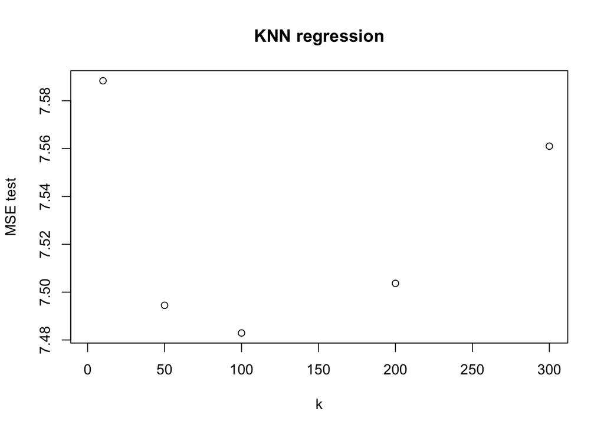

Figure 4: The Mean Squared Error (MSE) on the test set for a K-Nearest Neighbors (KNN) regression model with varying values of $k$ (10, 50, 100, 200, 300). The model was fitted to the training set of the `abalone` data set.

```r
library(caret)
knn_mse_test = NULL

for (k in c(10, 50, 100, 200, 300)){
  kmod <- knnreg(Rings ~ Length, data = train_data, k = k)
  yhat = predict(kmod, test_data)
  knn_mse_test[k] = mean((test_data$Rings - yhat)^2)
}

plot(knn_mse_test, type = "b", ylab = "MSE test", xlab = "k", main = "KNN regression")
```

**Exercise 24 (Bias-Variance Tradeoff:)** (1 point) Explain how the changes in test MSE across different values of $k$ illustrate the bias-variance tradeoff in the context of KNN regression.

**Exercise 25 (Model Performance)** (1 point) : What does a relatively high test MSE at low values of $k = 10$ indicate about the model’s performance in terms of overfitting or underfitting?

**Exercise 26 (Recommendations)** (1 point) Based on the observed MSE values, what would you recommend as the best choice for $k$? Justify your answer.

## Footnotes

[^1]: You can review the different data types in R and their usage by referring to this guide: [Data Types in R](https://statsandr.com/blog/data-types-in-r/).
[^2]: you can use inline R code by wrapping it in backticks with the r prefix `$\texttt{r} \texttt{ <R expression>}$`